# 05 — Classification of known K562 perturbation classes

# Cohort and evaluation scope

This classifier uses the focused Part 2 cohort, not the broad 12,000-cell coverage subset. The non-targeting control is included as a meaningful reference class. Random held-out cells test generalization to new cells from **known perturbation classes**, not unseen targets. Guide identities may occur in both splits, so this is not guide-wise generalization.

```r
library(Seurat)
library(ggplot2)
obj <- readRDS("data/processed/03_k562_perturbation_ready.rds")
stopifnot("gene" %in% colnames(obj[[]]), "sgID_AB" %in% colnames(obj[[]]))
class_counts <- as.data.frame(table(as.character(obj$gene)))
names(class_counts) <- c("class", "n_cells")
class_counts <- class_counts[order(-class_counts$n_cells), ]
stopifnot(nrow(class_counts)==13, min(class_counts$n_cells)>=100)
guide_counts <- aggregate(sgID_AB ~ gene, data=obj[[]], FUN=function(x) length(unique(as.character(x))))
names(guide_counts) <- c("class", "n_distinct_guide_pairs")
class_counts <- merge(class_counts, guide_counts, by="class", sort=FALSE)
class_counts <- class_counts[order(-class_counts$n_cells), ]
print(class_counts, row.names=FALSE)
```

```
##          class n_cells n_distinct_guide_pairs
##  non-targeting     493                     95
##           BUB1     249                      1
##          KIF11     249                      1
##         DONSON     248                      1
##         NUP205     248                      1
##           RPL3     248                      1
##           GAB2     247                      1
##           RRM2     247                      1
##          CHMP6     246                      1
##          NCBP2     246                      1
##        SLC39A9     246                      1
##          SNX15     246                      2
##          CPSF3     245                      1
```

```r
write.csv(class_counts, "results/05_class_counts.csv", row.names=FALSE)
cat("Total cells:", ncol(obj), "classes:", nrow(class_counts), "\n")
```

```
## Total cells: 3458 classes: 13
```

```r
rm(obj)
gc()
```

```
##           used  (Mb) gc trigger  (Mb) max used  (Mb)
## Ncells 3626528 193.7    6867908 366.8  5060460 270.3
## Vcells 6296194  48.1   43710790 333.5 51781957 395.1
```

### Interpretation

The model includes 12 targeting labels with 245–249 cells each and 493 non-targeting cells, all above the 100-cell minimum. The control class is roughly twice the size of a target class. Most targets have one observed guide pair, and this random cell split does not test guide-wise generalization.

# Fixed stratified split and model

The matching Part 2 H5AD supplies the sparse raw-count matrix. Class selection is verified against the saved Seurat cohort. A fixed 80/20 stratified split (seed 42) is made before fitting the 30-component TruncatedSVD and multinomial elastic-net logistic model. Per-cell total-count normalization and log1p transform are deterministic; SVD and logistic coefficients are fitted on training cells only. All genes enter training-only SVD, so there is no feature ranking learned from test cells. TruncatedSVD is not centered PCA.

```r
reticulate::use_python("C:/Python314/python.exe", required=TRUE)
```

```python
import anndata as ad
import joblib
import numpy as np
import pandas as pd
from pathlib import Path
from sklearn.model_selection import train_test_split
from sklearn.preprocessing import normalize
from sklearn.decomposition import TruncatedSVD
from sklearn.linear_model import LogisticRegression
from sklearn.metrics import accuracy_score, f1_score, confusion_matrix, classification_report

adata = ad.read_h5ad("data/processed/03_k562_powered_sample.h5ad")
expected = pd.read_csv("results/05_class_counts.csv")
actual = adata.obs.gene.astype(str).value_counts()
assert adata.n_obs == expected.n_cells.sum() == 3458
assert actual.to_dict() == dict(zip(expected["class"], expected.n_cells))
assert np.isfinite(adata.X.data).all() and np.all(adata.X.data >= 0)
assert np.all(adata.X.data == np.floor(adata.X.data)), "X must contain integer raw counts"
X = adata.X.tocsr()
y = adata.obs.gene.astype(str).to_numpy()
train_idx, test_idx = train_test_split(np.arange(len(y)), test_size=0.2, random_state=42, stratify=y)

def log_normalize(M):
    result = normalize(M, norm="l1", axis=1).tocsr() * 10000
    result.data = np.log1p(result.data)
    return result

X_train = log_normalize(X[train_idx])
X_test = log_normalize(X[test_idx])
svd = TruncatedSVD(n_components=30, random_state=42)
Z_train = svd.fit_transform(X_train)
Z_test = svd.transform(X_test)
model = LogisticRegression(penalty="elasticnet", solver="saga", l1_ratio=0.5,
                           C=1.0, max_iter=2000, random_state=42)
model.fit(Z_train, y[train_idx])
```

```
LogisticRegression(l1_ratio=0.5, max_iter=2000, penalty='elasticnet',
                   random_state=42, solver='saga')
```

```python
pred = model.predict(Z_test)
labels = sorted(np.unique(y))
majority = pd.Series(y[train_idx]).value_counts().idxmax()
baseline = float(np.mean(y[test_idx] == majority))
metrics = pd.DataFrame({"metric": ["accuracy", "macro_f1", "majority_baseline_accuracy", "train_cells", "test_cells", "classes"],
                        "value": [accuracy_score(y[test_idx], pred), f1_score(y[test_idx], pred, average="macro", labels=labels), baseline, len(train_idx), len(test_idx), len(labels)]})
report = pd.DataFrame(classification_report(y[test_idx], pred, labels=labels, output_dict=True, zero_division=0)).T
report = report.loc[labels].reset_index(names="class")
cm = pd.DataFrame(confusion_matrix(y[test_idx], pred, labels=labels), index=labels, columns=labels)
pd.DataFrame({"cell": adata.obs_names[test_idx], "truth": y[test_idx], "prediction": pred}).to_csv("results/05_test_predictions.csv", index=False)
pd.DataFrame({"class": labels, "train_cells": pd.Series(y[train_idx]).value_counts().reindex(labels).values,
              "test_cells": pd.Series(y[test_idx]).value_counts().reindex(labels).values}).to_csv("results/05_split_counts.csv", index=False)
metrics.to_csv("results/05_ml_metrics.csv", index=False)
report.to_csv("results/05_per_class_metrics.csv", index=False)
cm.rename_axis("truth").reset_index().to_csv("results/05_confusion_matrix.csv", index=False)
Path("models").mkdir(exist_ok=True)
joblib.dump({"svd": svd, "classifier": model, "genes": adata.var_names.tolist(),
             "normalization": "per-cell total 10000, log1p", "classes": labels,
             "seed": 42, "test_fraction": 0.2}, "models/05_multinomial_elastic_net.joblib")
```

```
## ['models/05_multinomial_elastic_net.joblib']
```

```python
print(metrics.to_string(index=False))
```

```
##                     metric       value
##                   accuracy    0.410405
##                   macro_f1    0.385637
## majority_baseline_accuracy    0.143064
##                train_cells 2766.000000
##                 test_cells  692.000000
##                    classes   13.000000
```

```python
print(pd.read_csv("results/05_split_counts.csv").to_string(index=False))
```

```
##         class  train_cells  test_cells
##          BUB1          199          50
##         CHMP6          197          49
##         CPSF3          196          49
##        DONSON          198          50
##          GAB2          198          49
##         KIF11          199          50
##         NCBP2          197          49
##        NUP205          198          50
##          RPL3          198          50
##          RRM2          198          49
##       SLC39A9          197          49
##         SNX15          197          49
## non-targeting          394          99
```

```python
print("SVD variance fraction:", round(float(svd.explained_variance_ratio_.sum()), 3))
```

```
## SVD variance fraction: 0.099
```

### Key finding

On 692 held-out cells from the 13 known classes, accuracy is 0.410 versus a 0.143 majority-class baseline (about 2.9-fold higher). This moderate performance indicates perturbation-associated signal beyond class prevalence, while macro-F1 of 0.386 shows uneven class discrimination. The fixed split fits SVD and elastic-net coefficients on 2,766 training cells; no cross-validation or guide-wise split was performed.

# Confusion matrix and per-class performance

```r
metrics <- read.csv("results/05_ml_metrics.csv")
per_class <- read.csv("results/05_per_class_metrics.csv")
cm <- read.csv("results/05_confusion_matrix.csv", check.names=FALSE)
print(metrics)
```

```
##                       metric        value
## 1                   accuracy    0.4104046
## 2                   macro_f1    0.3856368
## 3 majority_baseline_accuracy    0.1430636
## 4                train_cells 2766.0000000
## 5                 test_cells  692.0000000
## 6                    classes   13.0000000
```

```r
print(per_class[, c("class", "precision", "recall", "f1.score", "support")])
```

```
##            class precision     recall   f1.score support
## 1           BUB1 0.0000000 0.00000000 0.00000000      50
## 2          CHMP6 0.7073171 0.59183673 0.64444444      49
## 3          CPSF3 0.8666667 0.79591837 0.82978723      49
## 4         DONSON 0.4666667 0.56000000 0.50909091      50
## 5           GAB2 0.7735849 0.83673469 0.80392157      49
## 6          KIF11 0.5000000 0.04000000 0.07407407      50
## 7          NCBP2 0.9285714 0.79591837 0.85714286      49
## 8         NUP205 0.3333333 0.02000000 0.03773585      50
## 9           RPL3 0.4761905 0.20000000 0.28169014      50
## 10          RRM2 0.1034483 0.06122449 0.07692308      49
## 11       SLC39A9 0.5000000 0.36734694 0.42352941      49
## 12         SNX15 0.2000000 0.12244898 0.15189873      49
## 13 non-targeting 0.2111801 0.68686869 0.32304038      99
```

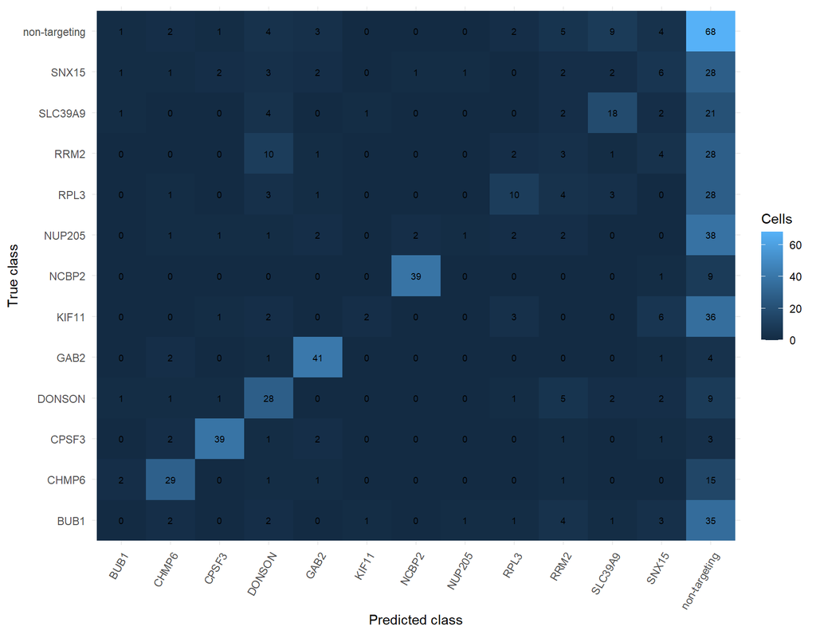

```r
conf_matrix <- as.matrix(cm[, -1, drop=FALSE])
rownames(conf_matrix) <- cm$truth
conf_long <- as.data.frame(as.table(conf_matrix))
names(conf_long) <- c("truth", "prediction", "n")
ggplot(conf_long, aes(prediction, truth, fill=n)) + geom_tile() + geom_text(aes(label=n), size=2.5) +
  labs(x="Predicted class", y="True class", fill="Cells") +
  theme_minimal() + theme(axis.text.x=element_text(angle=60, hjust=1))
```

### Interpretation

Per-class F1 ranges from 0 for BUB1 to 0.857 for NCBP2. The confusion matrix shows frequent predictions of non-targeting for NUP205 (38 of 50 test cells), KIF11 (36 of 50), and BUB1 (35 of 50). These errors indicate substantial overlap among the measured cell states; the evaluation does not address unseen perturbation targets.

## Key results

```r
cat("Classes:", metrics$value[metrics$metric=="classes"], "train/test cells:", metrics$value[metrics$metric=="train_cells"], "/", metrics$value[metrics$metric=="test_cells"], "\n")
```

```
## Classes: 13 train/test cells: 2766 / 692
```

```r
cat("Accuracy:", round(metrics$value[metrics$metric=="accuracy"], 3), "macro-F1:", round(metrics$value[metrics$metric=="macro_f1"], 3), "majority baseline:", round(metrics$value[metrics$metric=="majority_baseline_accuracy"], 3), "\n")
```

```
## Accuracy: 0.41 macro-F1: 0.386 majority baseline: 0.143
```

- **Evaluation cohort:** 13 known classes contribute 2,766 training and 692 test cells in a fixed stratified split.
- **Performance:** accuracy is 0.410 versus a 0.143 majority baseline, indicating moderate perturbation-associated signal.
- **Class balance:** macro-F1 is 0.386; frequent control predictions limit discrimination for several targets.
- **Scope:** held-out cells test known classes, not unseen targets or guide-wise generalization.